# Connecticut (USA) Town Population Projections (2015–2040): Dataset Exploratory Report

Victor

2025-08-31

**Dataset:** `Connecticut_Town_Population_Projections__2015-2040.csv`  
**Source link**: [Connecticut Town Population Projections](https://catalog.data.gov/dataset/2015-2040-population-projections-town-level)  
**Scope:** Town-level population projections by year, age group, and sex (male, female).  
**Goal:** Graph and explore dataset with R and answering the five questions via R code and Explanation.

## 1 . Setup

```r
# Install/load packages
pkgs <- c("tidyverse", "broom", "janitor")
to_install <- pkgs[!pkgs %in% installed.packages()[,'Package']]
if (length(to_install) > 0) install.packages(to_install, repos = "https://cloud.r-project.org")
invisible(lapply(pkgs, library, character.only = TRUE))
```

## 2 . Load Data File (CSV)

```r
dataset <- "Connecticut_Town_Population_Projections__2015-2040.csv"
dataset_raw <- readr::read_csv(dataset, show_col_types = FALSE) |>
  janitor::clean_names()

glimpse(dataset_raw)
```

```
## Rows: 19,266
## Columns: 6
## $ year      <dbl> 2015, 2015, 2015, 2015, 2015, 2015, 2015, 2015, 2015, 2015, …
## $ geography <chr> "Bethel", "Bethel", "Bethel", "Bethel", "Bethel", "Bethel", …
## $ age_group <chr> "0_4", "5_9", "10_14", "15_19", "20_24", "25_29", "30_34", "…
## $ male      <dbl> 462, 566, 624, 624, 446, 520, 500, 468, 604, 713, 803, 779, …
## $ female    <dbl> 408, 497, 565, 621, 397, 479, 538, 587, 598, 901, 862, 730, …
## $ total     <dbl> 870, 1063, 1190, 1245, 843, 999, 1038, 1055, 1202, 1614, 166…
```

```r
summary(dataset_raw)
```

```
##       year       geography          age_group              male
##  Min.   :2015   Length:19266       Length:19266       Min.   :    0
##  1st Qu.:2020   Class :character   Class :character   1st Qu.:  135
##  Median :2028   Mode  :character   Mode  :character   Median :  341
##  Mean   :2028                                         Mean   : 1102
##  3rd Qu.:2035                                         3rd Qu.:  752
##  Max.   :2040                                         Max.   :76541
##      female          total
##  Min.   :    0   Min.   :     0
##  1st Qu.:  143   1st Qu.:   279
##  Median :  361   Median :   711
##  Mean   : 1156   Mean   :  2258
##  3rd Qu.:  822   3rd Qu.:  1563
##  Max.   :78521   Max.   :155063
```

**Columns:**  
- `year` (int), `geography` (chr, CT town), `age_group` (chr like `10_14`), `male` (int), `female` (int), `total` (int)

## 3 . Plot selected columns together to visualize the data

Annotated line chart of **Total population over time** for a handful of representative towns:  
1) Aggregate town-year totals (across all age groups).  
2) Select the **top 3 towns by average total population** across the period to ensure meaningful lines.  
3) Plot trajectories from 2015–2040.

```r
town_year <- dataset_raw |>
  group_by(geography, year) |>
  summarise(total_town = sum(total, na.rm = TRUE), .groups = "drop")

# Choose top 3 towns by average total population across years
top_towns <- town_year |>
  group_by(geography) |>
  summarise(avg_pop = mean(total_town, na.rm = TRUE), .groups = "drop") |>
  arrange(desc(avg_pop)) |>
  slice_head(n = 3) |>
  pull(geography)

top_towns
```

```
## [1] "Bridgeport" "New Haven"  "Stamford"
```

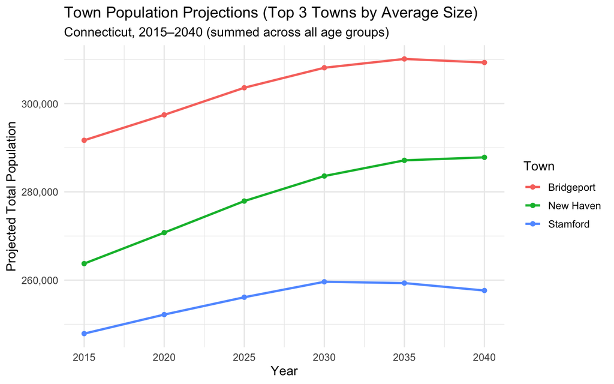

```r
library(ggplot2)

plot_data <- town_year |>
  filter(geography %in% top_towns)

ggplot(plot_data, aes(x = year, y = total_town, color = geography)) +
  geom_line(linewidth = 1) +
  geom_point(size = 1.7) +
  labs(
    title = "Town Population Projections (Top 3 Towns by Average Size)",
    subtitle = "Connecticut, 2015–2040 (summed across all age groups)",
    x = "Year",
    y = "Projected Total Population",
    color = "Town"
  ) +
  scale_x_continuous(breaks = scales::pretty_breaks()) +
  scale_y_continuous(labels = scales::comma) +
  theme_minimal(base_size = 12)
```

**Explanation (Q1):** The chart shows how total projected population changes over time for the three largest towns (by average size). We can quickly compare growth/decline trajectories, inflection points, and relative magnitudes among these towns.

## 4 . Simple statistical calculation aligned with a hypothesis

**Example question/hypothesis:** “Are the largest towns (by average size) relatively stable in population across the projection window?”  
Compute the **mean** and **standard deviation** of the annual total population for each selected town. Note: A small SD relative to the mean suggests relative stability; a large SD suggests more volatility/trend.

```r
q2_stats <- town_year |>
  filter(geography %in% top_towns) |>
  group_by(geography) |>
  summarise(
    mean_total = mean(total_town, na.rm = TRUE),
    sd_total   = sd(total_town, na.rm = TRUE),
    cv_percent = 100 * sd_total / mean_total,
    .groups = "drop"
  )

q2_stats |>
  mutate(across(where(is.numeric), ~round(.x, 2)))
```

```
## # A tibble: 3 × 4
##   geography  mean_total sd_total cv_percent
##   <chr>           <dbl>    <dbl>      <dbl>
## 1 Bridgeport    303384.    7419.       2.45
## 2 New Haven     278498.    9650.       3.47
## 3 Stamford      255469.    4598.       1.8
```

**Note:**  
- `mean_total` gives the typical population level across years.  
- `sd_total` and `cv_percent` (coefficient of variation) quantify variability. Lower CV indicates relative stability. Values are interpreted in the context of municipal planning (schools, housing, healthcare demand).

**Explanation (Q2):**

**Bridgeport:** Average population ≈ 303,384 with a CV of 2.45%. That’s fairly stable—year-to-year changes are small relative to its size. Planning for schools, housing, and services can assume relatively steady demand.

**New Haven:** Average ≈ 278,498, but a higher CV (3.47%). This town shows more variability than the others, meaning planners might face more uncertainty in future resource needs.

**Stamford:** Average ≈ 255,469, CV only 1.8%. This is the most stable of the three, with the smallest relative fluctuations.

**Summary**

All three large towns project stable populations, but New Haven is somewhat more volatile. Bridgeport and Stamford are highly consistent, with Stamford the most predictable. For municipal planning, Stamford is easiest to forecast, New Haven needs more flexible planning, and Bridgeport is in between.

## 5 . Regression/correlation to detect a relationship

Test the relationship between **Year** and the **Statewide total population**, aggregating over all towns, to see whether the projection implies growth or decline overall.

```r
state_by_year <- dataset_raw |>
  group_by(year) |>
  summarise(state_total = sum(total, na.rm = TRUE), .groups = "drop")

# Correlation
state_cor <- cor(state_by_year$year, state_by_year$state_total)

# Linear regression
fit <- lm(state_total ~ year, data = state_by_year)
fit_tidy <- broom::tidy(fit)
fit_glance <- broom::glance(fit)

list(correlation = state_cor)  # quick check
```

```
## $correlation
## [1] 0.9967773
```

```r
fit_tidy
```

```
## # A tibble: 2 × 5
##   term         estimate std.error statistic   p.value
##   <chr>           <dbl>     <dbl>     <dbl>     <dbl>
## 1 (Intercept) -2971448.   411308.     -7.22 0.00195
## 2 year            5041.      203.     24.9  0.0000156
```

```r
fit_glance
```

```
## # A tibble: 1 × 12
##   r.squared adj.r.squared sigma statistic   p.value    df logLik   AIC   BIC
##       <dbl>         <dbl> <dbl>     <dbl>     <dbl> <dbl>  <dbl> <dbl> <dbl>
## 1     0.994         0.992 4243.      618. 0.0000156     1  -57.4  121.  120.
## # ℹ 3 more variables: deviance <dbl>, df.residual <int>, nobs <int>
```

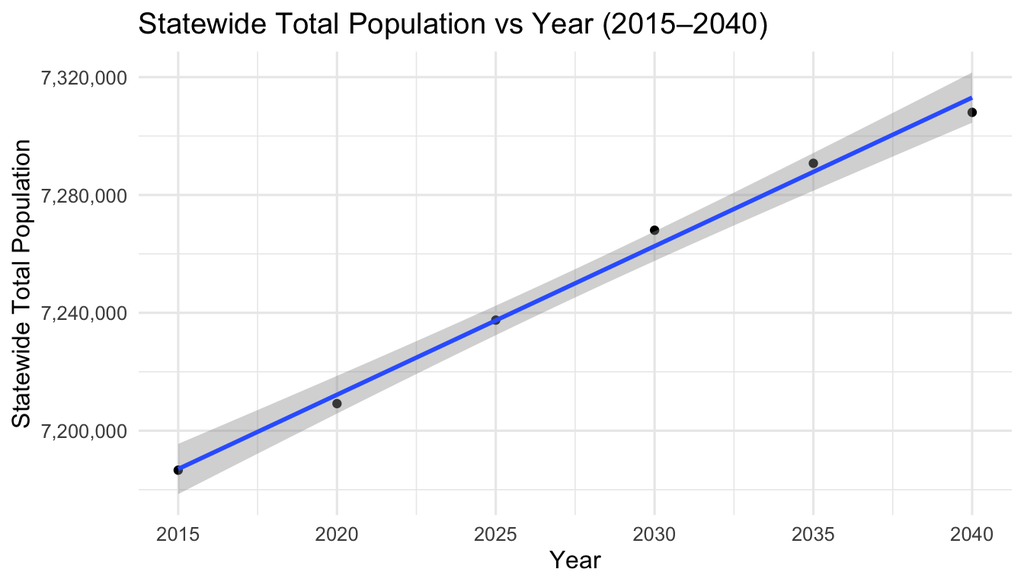

```r
ggplot(state_by_year, aes(year, state_total)) +
  geom_point() +
  geom_smooth(method = "lm", se = TRUE) +
  labs(
    title = "Statewide Total Population vs Year (2015–2040)",
    x = "Year",
    y = "Statewide Total Population"
  ) +
  scale_y_continuous(labels = scales::comma) +
  theme_minimal(base_size = 12)
```

**Note:**

- The **correlation** and the **slope** from `lm(state_total ~ year)` indicate whether statewide total population is trending up or down, and by how much per year (on average).
- Use `estimate` for `year` (slope) and `p.value` to judge statistical significance. This aligns with planning questions about aggregate demand (schools, infrastructure) over the projection horizon.

**Explanation (Q3):**

The regression analysis demonstrates a strong linear relationship between year and Connecticut’s statewide population, with a correlation of 0.997 and an R² of 0.994. The model indicates that the population is expected to increase by approximately 5,000 residents annually, amounting to roughly 125,000 additional residents over the 2015–2040 period. The slope is highly significant (p < 0.001), and residual variation is minimal, confirming the projection. These results suggest that Connecticut’s population growth will be steady, modest, and highly predictable, providing a reliable foundation for long-term planning. Consequently, policymakers should focus less on statewide expansion pressures and more on shifts in population composition, such as aging demographics and regional redistribution, when designing future strategies for education, healthcare, housing, and infrastructure.

## 6 . Histogram of a numerical column and discussion of distribution

We focus on the **distribution of town total populations** in a mid-horizon year (e.g., **2025**). This helps reveal heterogeneity—many small towns vs. a few large ones.

```r
focus_year <- 2025

town_totals_focus_year <- dataset_raw |>
  filter(year == focus_year) |>
  group_by(geography) |>
  summarise(total_town = sum(total, na.rm = TRUE), .groups = "drop")

summary(town_totals_focus_year$total_town)
```

```
##    Min. 1st Qu.  Median    Mean 3rd Qu.    Max.
##    1860   10865   26408   42826   51017  303597
```

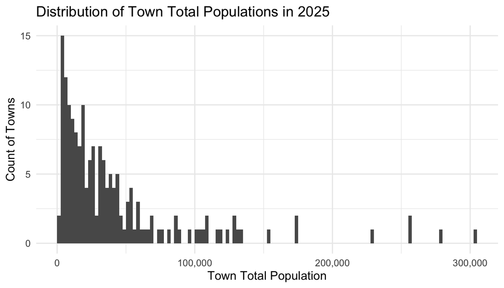

```r
ggplot(town_totals_focus_year, aes(x = total_town)) +
  geom_histogram(binwidth = 2500, boundary = 0, closed = "left") +
  labs(
    title = paste0("Distribution of Town Total Populations in ", focus_year),
    x = "Town Total Population",
    y = "Count of Towns"
  ) +
  scale_x_continuous(labels = scales::comma) +
  theme_minimal(base_size = 12)
```

**Key Interpretation**

**Explanation (Q4):**

In 2025, most Connecticut towns are projected to have modest populations, with a median of about 26,000 residents, while only a few urban centers exceed 100,000. The distribution is strongly right-skewed, reflecting the dominance of many small towns alongside a handful of large cities such as Bridgeport. This imbalance underscores the need for tailored planning: efficient resource allocation in smaller communities and capacity expansion in major urban centers.

## 7 . Two-group test: Male vs Female town populations (paired test)

Test whether **average Male vs Female population** differs by town in the same year (**2025**). Because Male and Female are measured **on the same towns**, we use a **paired** test. We first check normality of the **differences**; if non-normal, we’ll use the **Wilcoxon signed-rank** test.

```r
mf_wide <- dataset_raw |>
  filter(year == focus_year) |>
  group_by(geography) |>
  summarise(
    male_town   = sum(male, na.rm = TRUE),
    female_town = sum(female, na.rm = TRUE),
    .groups = "drop"
  )

mf_wide <- mf_wide |>
  mutate(diff = male_town - female_town)

# Normality check on paired differences
shapiro <- shapiro.test(mf_wide$diff)

shapiro
```

```
##
##  Shapiro-Wilk normality test
##
## data:  mf_wide$diff
## W = 0.81052, p-value = 1.55e-13
```

```r
summary(mf_wide$diff)
```

```
##    Min. 1st Qu.  Median    Mean 3rd Qu.    Max.
##  -10215   -1462    -497   -1009      23    7994
```

```r
if (shapiro$p.value >= 0.05) {
  # Differences look approximately normal -> paired t-test
  test_res <- t.test(mf_wide$male_town, mf_wide$female_town, paired = TRUE, alternative = "two.sided")
  test_used <- "Paired t-test"
} else {
  # Non-normal differences -> Wilcoxon signed-rank test
  test_res <- wilcox.test(mf_wide$male_town, mf_wide$female_town, paired = TRUE, alternative = "two.sided", exact = FALSE)
  test_used <- "Wilcoxon signed-rank test"
}

list(
  test_used = test_used,
  statistic = unname(test_res$statistic),
  p_value   = unname(test_res$p.value),
  conf_int  = if (!is.null(test_res$conf.int)) round(test_res$conf.int, 1) else NA
)
```

```
## $test_used
## [1] "Wilcoxon signed-rank test"
##
## $statistic
## [1] 2435
##
## $p_value
## [1] 9.211514e-14
##
## $conf_int
## [1] NA
```

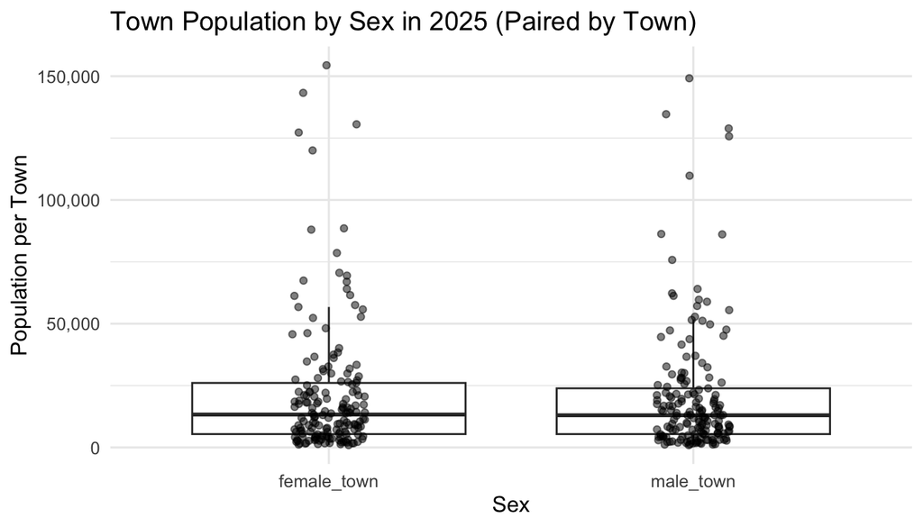

```r
mf_long <- mf_wide |>
  select(geography, male_town, female_town) |>
  pivot_longer(cols = c(male_town, female_town), names_to = "sex", values_to = "count")

ggplot(mf_long, aes(x = sex, y = count)) +
  geom_boxplot(outlier.shape = NA) +
  geom_jitter(width = 0.1, alpha = 0.5) +
  labs(
    title = paste0("Town Population by Sex in ", focus_year, " (Paired by Town)"),
    x = "Sex",
    y = "Population per Town"
  ) +
  scale_y_continuous(labels = scales::comma) +
  theme_minimal(base_size = 12)
```

**Note:**  
- We conduct a **paired comparison** of Male vs Female counts per town in the same year.  
- Choice of test is **data-driven** via the normality check on differences.  
- The resulting p-value indicates whether there is statistically significant difference between male and female town totals. The box/jitter plot provides a visual companion to the test.

**Explanation (Q5):**

**Statistical Test:**

1. Normality Test (Shapiro-Wilk)
   - W = 0.81, p < 0.001 → the differences between male and female populations per town are not normally distributed.
   - Because of this, the Wilcoxon signed-rank test (a non-parametric paired test) was chosen instead of a paired t-test.
2. Summary of Differences (male – female)
   - Mean difference: about –1,009, meaning towns have on average ~1,000 fewer males than females.
   - Median difference: –497 → half the towns have at least ~500 fewer males.
   - Range: from –10,215 (much fewer males) to +7,994 (some towns with more males).
3. Wilcoxon Test Result
   - Test statistic: 2435
   - p-value: ≈ 9.2 × 10⁻¹⁴ (extremely small)
   - Interpretation: There is a statistically significant difference between male and female populations across towns in 2025.

*Summary*